# Time Series Analysis

#### Homework5 201811526 이은주

### 2. gasrx

gasrx data는 컨트롤러를 끄고 가스 용해로의 가스 입력 속도를 9초마다 판독한 데이터입니다. 예측을 위한 ARIMA 모델 선택을 위해 gasrx 데이터의 여러 특징을 알아보고 가장 좋은 모델을 최종 선택하겠습니다.

#### [STEP 1] 시계열 데이터 처리

```r
gasrx = read.table("gasrx.txt")
gasrx_ts = ts(gasrx, start=c(0,0), frequency=60/9)
head(gasrx_ts)
```

```
## Time Series:
## Start = -0.15
## End = 0.6
## Frequency = 6.66666666666667
##          V1
## [1,] -0.109
## [2,]  0.000
## [3,]  0.178
## [4,]  0.339
## [5,]  0.373
## [6,]  0.441
```

컨트롤러를 끄기 시작한 0초(시작)부터 9초간격으로 판독한 데이터이므로 1분동안 60/9번 판독함을 고려하여 시계열 데이터로 변환하였습니다.

#### [STEP 2] 시계열 그래프

gasrx 데이터의 시계열 그래프를 통해 시간 흐름에 따른 특징을 알아봅니다.

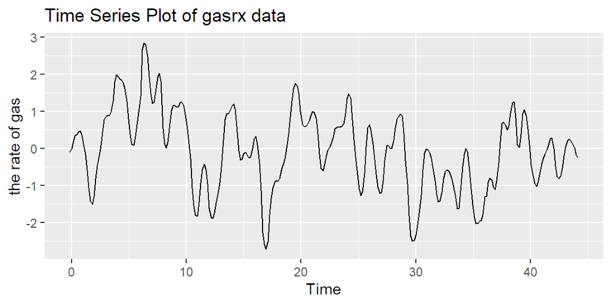

```r
autoplot(gasrx_ts) + ylab("the rate of gas") +
  ggtitle("Time Series Plot of gasrx data")
```

시간의 흐름에 따라 각 관측값을 보면 가스 입력 속도가 빨라졌다가 느려지는 즉, 진동하는 것처럼 보입니다.  
또한 전반적으로는 컨트롤러를 끄고 나서 시간이 지날수록 가스 입력 속도가 느려지는 듯한 추세를 보입니다.

#### [STEP 3] ACF, PACF

ACF(자기상관함수) : t시간의 차이가 있는 두 관측값의 상관성  
PACF(부분자기상관함수) : 상관성을 비교하기 위한 두 관측값 외 다른 관측값을 제외 후, 두 관측값의 상관성

AR(p) : ACF가 지수적으로 또는 sin함수 형태로 감소하며, PACF가 p+1차 이후 절단되어 보입니다.  
MA(q) : ACF가 q+1차 이후 절단되며, PACF가 지수적으로 또는 sin함수 형태로 감소합니다.  
ARMA(p,q) : ACF는 q-p+1차부터, PACF는 p-q+1차부터 지수적으로 또는 sin함수 형태로 감소합니다.

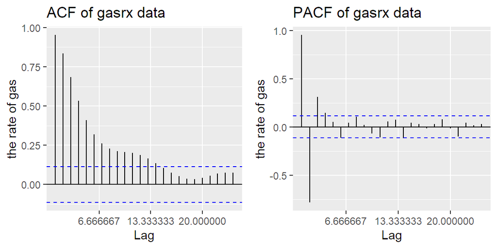

```r
p1 = ggAcf(gasrx_ts) + ylab("the rate of gas") + ggtitle("ACF of gasrx data")
p2 = ggPacf(gasrx_ts) + ylab("the rate of gas") + ggtitle("PACF of gasrx data")
grid.arrange(p1, p2, ncol=2)
```

ACF가 지수적으로 느리게 감소하고 PACF는 시차5 이후부터 절단된 것으로 보이는 것을 보아 AR(4) 모델을 임의로 선택합니다.  
하지만 시차4 시점에서의 PACF값이 유의수준에 매우 가까우므로 AR(3) 모델 또한 고려하도록 합니다.

#### [STEP 4] Best model 선택

train data : 모델 선택을 위한 학습용 데이터  
test data : 최종 선택한 모델의 최종 성능 평가를 위한 데이터

gasrx 데이터를 0초부터 36분(9초간격으로 240번째)까지 train data, 37분(241번째)부터 44.4분(296번째)까지 test data로 나누어 위에서 임의로 선택한 AR(3), AR(4) model과 자동선택된 ARMA model을 비교해 보고 가장 좋은 모델을 선택합니다.

```r
train_gasrx = gasrx_ts[1:240]
test_gasrx = gasrx_ts[241:296]
```

##### (1) 모델 적합

- AR(3) model

```r
arimaModel_3 = arima(train_gasrx, order=c(3,0,0));print(arimaModel_3)
```

```
##
## Call:
## arima(x = train_gasrx, order = c(3, 0, 0))
##
## Coefficients:
##          ar1      ar2     ar3  intercept
##       1.9508  -1.3055  0.2988    -0.0776
## s.e.  0.0614   0.1119  0.0617     0.2220
##
## sigma^2 estimated as 0.03822:  log likelihood = 48.84,  aic = -87.68
```

AR(3) model : $Y_t$ = - 0.0776 + 1.9508$Y_{t-1}$ - 1.3055$Y_{t-2}$ + 0.2988$Y_{t-3}$ + $a_t$, $a_t$:WN  
* AR(4) model

```r
arimaModel_4 = arima(train_gasrx, order=c(4,0,0));print(arimaModel_4)
```

```
##
## Call:
## arima(x = train_gasrx, order = c(4, 0, 0))
##
## Coefficients:
##          ar1      ar2      ar3     ar4  intercept
##       1.9048  -1.1044  -0.0009  0.1536    -0.0932
## s.e.  0.0635   0.1385   0.1386  0.0638     0.2597
##
## sigma^2 estimated as 0.0373:  log likelihood = 51.7,  aic = -91.4
```

AR(4) model : $Y_t$ = -0.0932 + 1.9048$Y_{t-1}$ - 1.1044$Y_{t-2}$ - 0.0009$Y_{t-3}$ + 0.1536$Y_{t-4}$ + $a_t$, $a_t$:WN

- Autoarima model

```r
AutoarimaModel = auto.arima(train_gasrx); print(AutoarimaModel)
```

```
## Series: train_gasrx
## ARIMA(2,1,1)
##
## Coefficients:
##          ar1      ar2      ma1
##       1.5141  -0.7490  -0.5898
## s.e.  0.0790   0.0564   0.1159
##
## sigma^2 estimated as 0.03909:  log likelihood=49.05
## AIC=-90.11   AICc=-89.93   BIC=-76.2
```

ARIMA(2,1,1) model = $\Delta Y_t$ = 1.5141$\Delta Y_{t-1}$ - 0.7490$\Delta Y_{t-2}$ - 0.5898$a_{t-1}$ + $a_t$, $a_t$:WN

세개의 모델의 AIC를 보면, AR(3): -87.68, AR(4): -91.4, ARMA(2,1,1): -90.11로 AR(4) 모델의 AIC값이 가장 작아 가장 모델이 적합한 것으로 보입니다. 하지만 이때 모델이 복잡할수록 좋은 모델이라고도 할 수 없으므로 각 모델의 다른 특징 또한 확인 후 최종 모델을 판단하도록 합니다.

##### (2) 정상성 : 시간이 흐름에도 확률적 성질이 변하지 않는 성질

모델의 특성방정식 근 절대값이 1보다 클 때, 정상성을 만족합니다.  
즉 역근의 절대값이 1보다 작아야 하므로 원 안에 역근이 있으면 정상성을 만족한다고 할 수 있습니다.

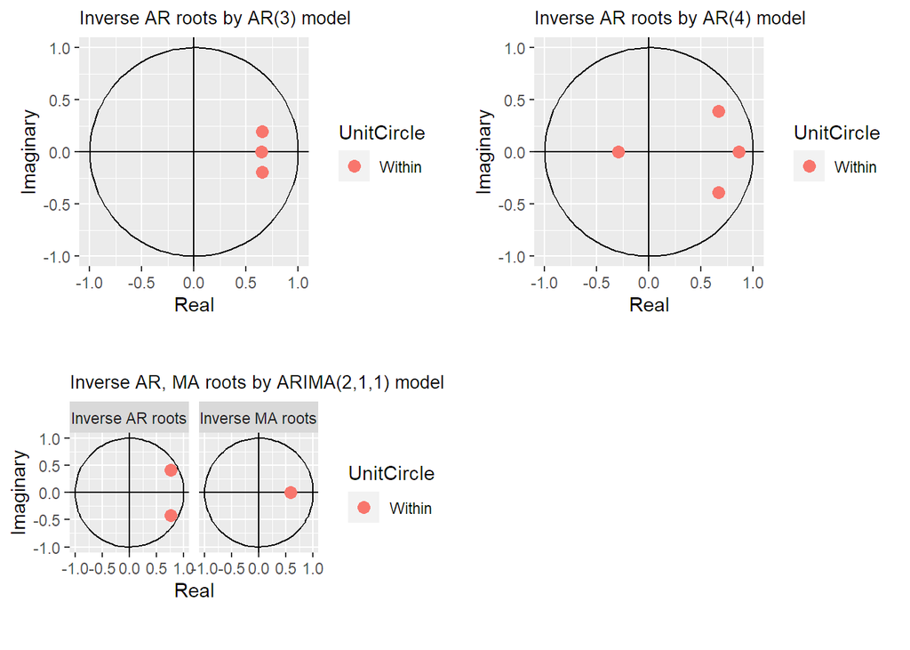

```r
p1=autoplot(arimaModel_3) + ggtitle("Inverse AR roots by AR(3) model") +
  theme(plot.title = element_text(size=10))
p2=autoplot(arimaModel_4) + ggtitle("Inverse AR roots by AR(4) model") +
  theme(plot.title = element_text(size=10))
p3=autoplot(AutoarimaModel) + ggtitle("Inverse AR, MA roots by ARIMA(2,1,1) model") +
  theme(plot.title = element_text(size=10))
grid.arrange(p1,p2,p3, ncol=2)
```

세개의 모델 모두 원 안에 역근이 있는 것으로 보아 정상성을 만족하는 것으로 보입니다.

##### (3) 잔차의 독립성 및 정규성

잔차의 분포를 통해 정규성을 확인하고, ACF값이 유의수준 내에 있다면 잔차의 자기상관성이 없다고 할 수 있습니다.  
잔차의 독립성에 대해 정확히 알아보기 위해 Ljung-Box test 검정(H0:잔차가 독립) 또한 진행합니다.

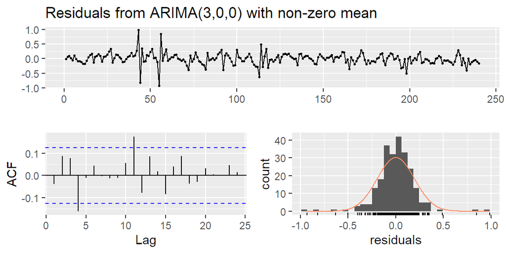

```
##
##  Ljung-Box test
##
## data:  Residuals from ARIMA(3,0,0) with non-zero mean
## Q* = 11.56, df = 6, p-value = 0.07253
##
## Model df: 4.   Total lags used: 10
```

```r
checkresiduals(arimaModel_3)
```

AR(3) 모델의 잔차 분포를 보았을 때 정규성을 따르지만 유의수준을 넘는 값이 존재하므로 검정 결과에 따라 잔차의 독립성을 판단하도록 하였습니다. AR(3) 모델은 p값이 0.07253으로 잔차가 독립이라는 귀무가설을 기각하지 않습니다. 즉, 잔차가 독립입니다.

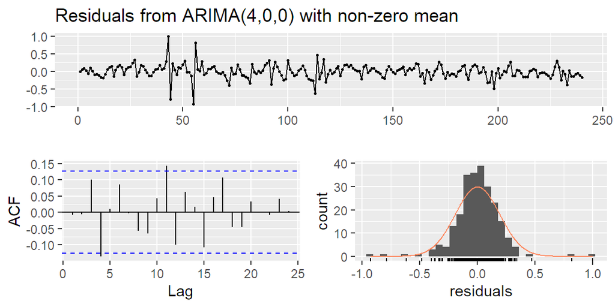

```
##
##  Ljung-Box test
##
## data:  Residuals from ARIMA(4,0,0) with non-zero mean
## Q* = 11.267, df = 5, p-value = 0.04633
##
## Model df: 5.   Total lags used: 10
```

```r
checkresiduals(arimaModel_4)
```

AR(4) 모델의 잔차 분포를 보았을 때 정규성을 따르지만 유의수준을 넘는 값이 존재하므로 검정 결과에 따라 잔차의 독립성을 판단하도록 하였습니다. AR(4) 모델은 p값이 0.04633으로 잔차가 독립이라는 귀무가설을 기각하합니다. 즉, 잔차가 독립이라 할 수 없어 잔차의 조건을 만족하지 않습니다. 이에 따라 AR(4) 모델은 제외하도록 하겠습니다.

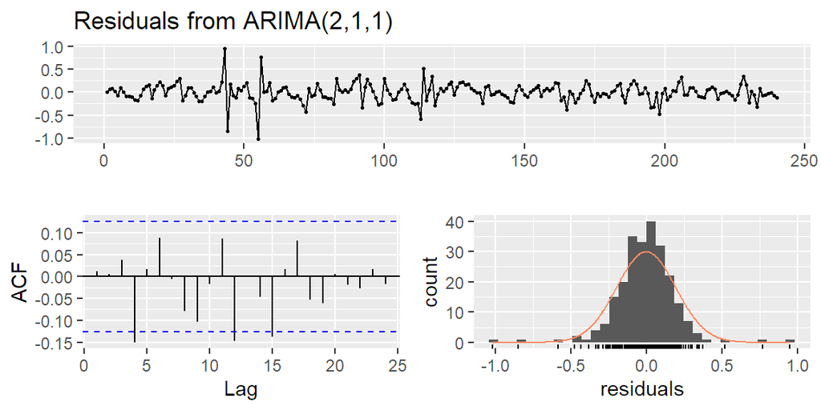

```
##
##  Ljung-Box test
##
## data:  Residuals from ARIMA(2,1,1)
## Q* = 12.336, df = 7, p-value = 0.09003
##
## Model df: 3.   Total lags used: 10
```

```r
checkresiduals(AutoarimaModel)
```

ARIMA(2,1,1) 모델의 잔차 분포를 보았을 때 정규성을 따르지만 ACF값이 유의수준을 넘는 값이 존재하므로 검정 결과에 따라 잔차의 독립성을 판단하도록 하였습니다. ARIMA(2,1,1) 모델은 p값이 0.09003으로 잔차가 독립이라는 귀무가설을 기각하지 않습니다. 즉, 잔차가 독립입니다.

##### (4) 예측 및 정확성

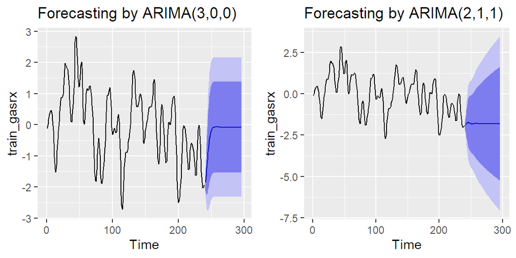

```r
forecast1 = forecast::forecast(arimaModel_3, h=56)
forecast2 = forecast::forecast(AutoarimaModel, h=56)

p1 = autoplot(forecast1) + ggtitle("Forecasting by ARIMA(3,0,0)")
p2 = autoplot(forecast2) + ggtitle("Forecasting by ARIMA(2,1,1)")
grid.arrange(p1,p2, ncol=2)
```

```r
accuracy(arimaModel_3)
```

```
##                        ME      RMSE       MAE MPE MAPE      MASE        ACF1
## Training set 4.288234e-05 0.1954898 0.1350348 Inf  Inf 0.5165799 -0.03787891
```

```r
accuracy(AutoarimaModel)
```

```
##                        ME      RMSE       MAE MPE MAPE      MASE       ACF1
## Training set -0.004223467 0.1960639 0.1359327 Inf  Inf 0.5200146 0.01195545
```

train data에 대한 RMSE 기준으로 정확성을 판단하여 두 모델을 비교하면 AR(3) 모델이 더욱 작은 것으로 보아 정확해보입니다. 이에 따라 AR(3) model을 최종 선택합니다. (RMSE : 여러 정확성 나타내는 지표 중 하나로 작을수록 정확성이 높다고 판단합니다.)

##### (5) test data 예측값, 실제값 비교

최종 선택한 AR(3) model에 대해 test data의 실제값과 예측값의 오차를 통해 모델의 성능을 확인합니다.

```r
df.forecast1 = data.frame(forecast1)
regr.eval(test_gasrx, df.forecast1$Point.Forecast)
```

```
##       mae       mse      rmse      mape
## 0.4777535 0.3436049 0.5861782       Inf
```

RMSE가 0.586으로 매우 0에 가까운 것으로 보아 AR(3) 모델의 예측 성능이 좋은 것으로 보입니다.